# Sampling, Point Estimation and Central Limit Theorem in R (Introduction)

## 0. Concept Review

#### **A. Sampling**

**Sampling** is the selection of observations from a “population of interest” to gain insights and draw inferences about that population.

To avoid biases, sampling should be done very carefully. A sample should be **random** and have the **same characteristics** of the population it is representing (e.g. blood type, height, sex, etc).

Statisticians have many ways to achieve this, however, we’ll focus on random sampling using the **sample()** and **replicate()** functions in R for this project/assignment.

#### **B. Point Estimation**

**Point Estimation** is a single number calculated from sample data and used to estimate a population parameter. For example:

- Point Estimate of the Population Mean μ is the Sample Mean or x̄.
- Point Estimate for the Population Variance σ² is the Sample Variance s².

#### **C. Central Limit Theorem**

Some key takeaways from the **Central Limit Theorem (CLT):**

- The distribution of the sample means has an approximate normal distribution as long as the sample size is large enough (> 30 observations) and all samples have the same size
- This holds true for other sample statistics, such as the sample proportion
- Law of Large Numbers - if you take samples of larger and larger size from any population, then the sample mean (x̄) will approach the population mean (μ)
- Since the standard deviation is σ/√n , as n increases, the standard deviation (variance) gets smaller.

## 1. Library

Load the necessary libraries into this R studio session.  
**Note:** some packages may need to be installed. Use the install.package() function or search for the package at R Studio Menu Bar > Tools > Install Packages.

Many libraries used below are **not necessary** to complete this assignment.

```r
library(tidyr)
library(readxl)
library(dplyr)
library(stringr)
library(writexl)
library(ggplot2)
library(httpuv)
library(googledrive)
library(googlesheets4)
library(knitr)
library(xtable)
library(glue)
library(rmdformats)
library(bookdown)
```

## 2. Loading Files

For this assignment, our file and directory are hosted by Google drive. As such, we need to authorize access to the drive and read the necessary file(s) into this R studio session.

The code below give us access to our Google drive. Check the console output for additional instructions.

```r
googledrive::drive_auth()
sample_data2 = read_sheet(gs4_find('sample_data2'))
```

Next, we need to read and assign the Google spreadsheet to a variable.

```r
sample_data2 = read_sheet(gs4_find('sample_data2'))
```

Let’s take a look at the first five rows of the data frame to ensure the import was successful and correct.

```r
view_sample = sample_data2[1:5,]
kable(view_sample, align = "llllcccc", caption = "Sample Data - 2020 Population by County and State")
```

Sample Data - 2020 Population by County and State

| Census_Year | State_County | County | State | Population | State_Code | Unique_State_County | County_Code |
| --- | --- | --- | --- | --- | --- | --- | --- |
| 2020 | Coahoma County, Mississippi | Coahoma County | Mississippi | 22124 | 28 | 28-027 | 027 |
| 2020 | Jasper County, Mississippi | Jasper County | Mississippi | 16383 | 28 | 28-061 | 061 |
| 2020 | Jones County, Mississippi | Jones County | Mississippi | 68098 | 28 | 28-067 | 067 |
| 2020 | Choctaw County, Mississippi | Choctaw County | Mississippi | 8210 | 28 | 28-019 | 019 |
| 2020 | Hancock County, Mississippi | Hancock County | Mississippi | 47632 | 28 | 28-045 | 045 |

## 3. Summary Statistics

We can run the summary function to get a full panel of descriptive statistics (see code below).

For this assignment, the population mean is the only parameter necessary. Since a single population observation equates to one person, we’re also going to round the population mean to the nearest number.

```r
dstats = summary(sample_data2)

pop_mean = round(mean(sample_data2$Population))
glue("Population Mean (Mu): {pop_mean}")
```

```
## Population Mean (Mu): 102930
```

## 4. Point Estimate (μ): *n* sizes

This assignment assumes that we **DO NOT** have all the population data which is why we’re using the point estimate method to derive the best estimation of our population mean.

**Important Note:** each time we run the code below, we’re sampling from the total population. Every occurrence uses a different combination of observations to calculate our point estimate. As a result, we will always produce a **different point estimate of the sample mean**.

#### Point Estimation (20 observations)

Using the sample function to select **20** random samples followed by the mean function to derive the average.

```r
sample_20 = mean(sample(sample_data2$Population, size = 20))
glue("Point Estimate (20 Observations): {sample_20}")
```

```
## Point Estimate (20 Observations): 116997
```

The variance between our population mean of 102930 and this point estimation is due to randomness. As we increase the number of observations used, our point estimations will moving closer and closer to the observed population mean.

#### Point Estimation (200 observations)

Using the sample function to select **200** random samples (10x the previous sample) followed by the mean function to derive the average.

```r
sample_200 = mean(sample(sample_data2$Population, size = 200))
glue("Point Estimate (200 Observations): {sample_200}")
```

```
## Point Estimate (200 Observations): 113301.26
```

#### Point Estimation (2000 observations)

```r
sample_2000 = mean(sample(sample_data2$Population, size = 2000))
glue("Point Estimate (2000 Observations): {sample_2000}")
```

```
## Point Estimate (2000 Observations): 108691.28
```

## 5. Point Estimate (μ): Replicate

In this section, we calculate the sample mean using a fixed sample of 100 observations. Then we use the replicate function to repeat this process **n** number of times and examine how closely we can approximate the true population mean.

```r
rsample_40 = mean(replicate(40,mean(sample(sample_data2$Population, size=100))))
print(rsample_40)
```

```
## [1] 100955.9
```

Increasing the number of replications to **400** would result in a mean of mean even closer to the population mean:

```r
rsample_400 = mean(replicate(400,mean(sample(sample_data2$Population, size=100))))
print(rsample_400)
```

```
## [1] 103293
```

Let’s set the replicate function to **4000** and compare to the population mean:

```r
rsample_4000 = mean(replicate(4000,mean(sample(sample_data2$Population, size=100))))
print(rsample_4000)
```

```
## [1] 102369.1
```

The tables below aggregates the results from using sampling and sompling with replication. Two key takeways:

1. Increasing the sample size will move us closer to the true population mean.
2. Increasing the sample size via replication is a faster and more efficient method of getting as close as possible to our population mean.

1. Point Estimation of Mean with Sampling

| n | x | $\mu$ | $\Delta$(%) |
| --- | --- | --- | --- |
| 20 | 116997.0 | 102930 | -0.1202339 |
| 200 | 113301.3 | 102930 | -0.0915370 |
| 2000 | 108691.3 | 102930 | -0.0530059 |

2. Point Estimation of Mean (Fixed Sample with Replication)

[output not shown]

## 6. Histogram of Means

We can analyze the histograms of the previous “mean of means” to illustrate how an increase in the frequency of computed sample means impacts the distribution of means.

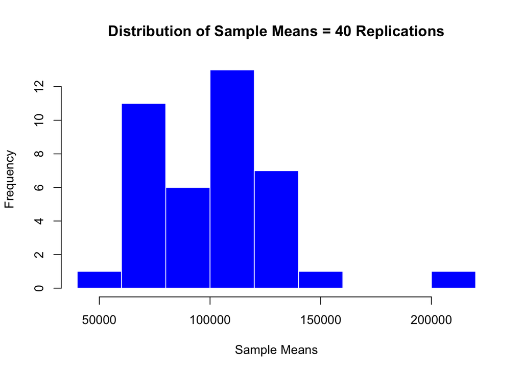

```r
hist(replicate(40,mean(sample(sample_data2$Population, size=100),simplify=TRUE)), xlab = 'Sample Means', ylab = 'Frequency', main = 'Distribution of Sample Means = 40 Replications', col = 'blue', border = 'white')
```

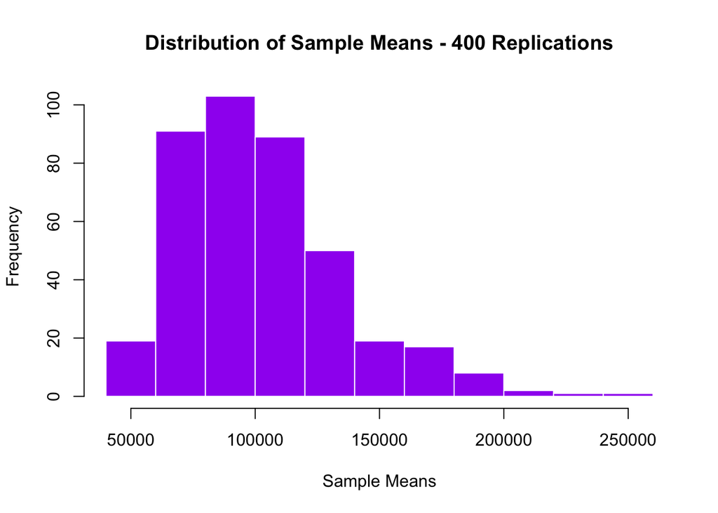

```r
hist(replicate(400,mean(sample(sample_data2$Population, size=100),simplify=TRUE)), xlab = 'Sample Means', ylab = 'Frequency', main = 'Distribution of Sample Means - 400 Replications', col = 'purple', border = 'white')
```

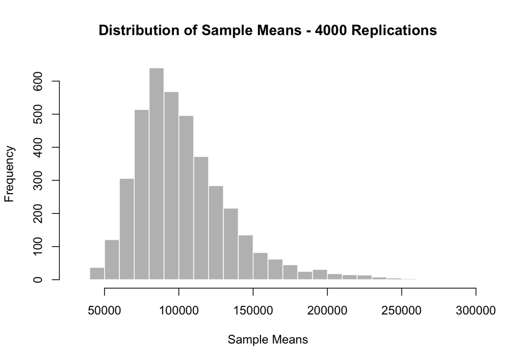

```r
hist(replicate(4000,mean(sample(sample_data2$Population, size=100),simplify=TRUE)), xlab = 'Sample Means', ylab = 'Frequency', main = 'Distribution of Sample Means - 4000 Replications', col = 'grey', border = 'white', breaks = 30)
```